# Team members:

### Homoud Al-Ghanim \ 2132131306

### Phenomenom:

#### Exploratory Data Analysis(EDA) on cyber security using social media for the most active users and countries

### Used Packages:

| package name | uses |
| --- | --- |
| Pandas | read\create Dataframe |
| Tweepy | Import tweets from twitter |
| Altair | Data Visualization and plots |
| NLTK | analyze text and do sentiment analysis |
| Matplotlib | Data Visualization |
| Numpy | help with mathematical functions |
| WordCloud | Create a word cloud image |
| Basemap | Create map using the dataframe |

### Interesting Variables

```python
df[['account_Name','userProfile_created_time','tweet','tweet_sent_Time','tweet_language','source']].head(10)
```

|  | account_Name | userProfile_created_time | tweet | tweet_sent_Time | tweet_language | source |
| --- | --- | --- | --- | --- | --- | --- |
| 0 | rachealgudaiti1 | 2017-03-25 20:47:39 | RT @iFutureTek: Key #GDPR &amp; #NewYork #Cybe... | 2017-12-17 17:36:43 | en | Twitter for Android |
| 1 | eescobar8127 | 2012-06-24 17:46:49 | RT @iFutureTek: #CyberSecurity Attack is a glo... | 2017-12-17 17:36:43 | en | Twitter for Android |
| 2 | blystoneraclng | 2014-04-15 04:06:25 | RT @iFutureTek: #CyberSecurity Attack is a glo... | 2017-12-17 17:36:40 | en | Twitter for Android |
| 3 | JeremyhPh0to | 2012-06-24 17:11:50 | RT @iFutureTek: #CyberSecurity Attack is a glo... | 2017-12-17 17:36:39 | en | Twitter for Android |
| 4 | QueenB__Speakn | 2015-03-02 02:31:01 | RT @iFutureTek: #CyberSecurity Attack is a glo... | 2017-12-17 17:36:38 | en | Twitter for Android |
| 5 | stefenie_8206 | 2014-03-26 13:35:31 | RT @iFutureTek: #CyberSecurity Attack is a glo... | 2017-12-17 17:36:35 | en | Twitter for Android |
| 6 | EmilyBrianne11 | 2011-12-18 01:17:52 | RT @iFutureTek: #CyberSecurity Attack is a glo... | 2017-12-17 17:36:33 | en | Twitter for Android |
| 7 | CallttaH | 2011-05-02 14:23:04 | RT @iFutureTek: #CyberSecurity Attack is a glo... | 2017-12-17 17:36:32 | en | Twitter for Android |
| 8 | bPositive_ | 2009-04-01 01:45:53 | After #FBI Director #ComeyFiring, any attempt ... | 2017-12-17 17:36:31 | en | Twitter Web Client |
| 9 | Omar_S558 | 2011-03-26 12:50:25 | RT @iFutureTek: #CyberSecurity Attack is a glo... | 2017-12-17 17:36:30 | en | Twitter for Android |

## The number of tweets has been collected = 202,325

# Result:

## 1.

### Variables identification

| Column Name | Variable definition | Data Type | Missing data report | distribution of the data | level of analysis |
| --- | --- | --- | --- | --- | --- |
| account_Name | The sender profile account name | String | False | No Distribution | User |
| userProfile_created_time | The time of when the users created their profile | continues(datetime64) | False | No Distribution | User |
| location | The location the user put on their profile page(not all the time true) | String | True(44,397) | No Distribution | User |
| following_count | The number of account's the user follows | Continues(int64) | False | minimum(0),maximum(1148424) | User |
| followers_count | The number of account's follow this user | Continues(int64) | False | minimum(0),maximum(19181792) | User |
| account_total_tweets | The Total tweets the user sent from the creation of the profile | Continues(int64) | False | minimum(1),maximum(8271116) | User |
| tweet_sent_Time | The tweet creation or retweeted time | Continues(datetime64) | False | No Distribution | Tweet |
| tweet | The content of the tweet that has been sent | String | False | No Distribution | Tweet |
| tweet_language | The language of the tweet that has been sent | String | False | No Distribution | Tweet |
| hashtags | The hashtags inside the tweets if available | String | False | No Distribution | Tweet |
| mentions | The account's that has been mentioned in the tweet | String | False | No Distribution | User |
| reply_to_user | The user this tweet is being replied to | String | True(197,538) | No Distribution | Tweet |
| geo | The place or coordinates that the tweet been sent from(mostly accurate) | String | True(202,072) | No Distribution | Tweet |
| retweet_count | The number of times this tweet has been retweeted | Continues(int64) | False | minimum(0),maximum(102621) | Tweet |
| favorite_count | The number of times this tweet has been liked | Continues(int64) | False | minimum(0),maximum(10990) | Tweet |
| source | The source or the platform of the device the tweet been sent from | String | False | No Distribution | Tweet |
| url | The url of the tweet | String | False | No Distribution | Tweet |

# 2.

### Transformed Variables

| Variable Names | Variable description | Steps in transformation | level of analysis |
| --- | --- | --- | --- |
| sentiment_analysis | The expression of the tweet if it was negative, neutral or positive | Used NLP SentimentIntensityAnalyzer provided by vaderSentiment package to get the sentiment expression | Tweets |
| sentiment_score | The score of the expression if it was extreme or not | Used NLP SentimentIntensityAnalyzer provided by vaderSentiment package to get the sentiment score | Tweets |
| top5_active_users | The most 5 active users by number of tweets they sent | used value count to get the most common users who sent tweets | Users |
| top3_source | The most used platform to sent a tweet | used value counts to get the most used platform from all the dataframe | Tweets |

# 3.

### insights:

## insights:

## Extreme values

```python
df[['account_Name','tweet','sentiment_analysis','sentiment_score']].sort_values(by='sentiment_score',ascending=False).head()[0:2]

# The 1st positive sentiment isn't related to cyber security
```

|  | account_Name | tweet | sentiment_analysis | sentiment_score |
| --- | --- | --- | --- | --- |
| 39585 | LilJamiee_ | @niacerise HAPPY BIRTHDAY DEAR. WULLNP. AGE ... | positive sentiment | 0.9906 |
| 161338 | CyFlare_SOC | We are so excited to be working with Rochester... | positive sentiment | 0.9850 |

```python
print(df.tweet[39585]+'\n')

print(df.tweet[161338])
# This tweet was the extreme positive sentiment in the dataframe
```

```
@niacerise HAPPY BIRTHDAY DEAR.  WULLNP.  AGE ON WITH GRACE FOR EXPLOITS. I PRAY THAT DOUBLE PORTIONS OF BLESSINGS AND LOVE AND FAVOUR AND EVERYTHING GOOD YOU WANT BE YOURS IN JESUS NAME,  AMEN AND I ALSO PRAY THAT YOU ACCOMPLISH THE ESSENCE OF YOUR EXISTENCE PREDESTINED BY GOD.  HBD

We are so excited to be working with Rochester Institute of Technology working with the best and brightest new talent in the cyber security market.  We cannot wait for the amazing new ideas and innovation to come. CyFlare is a place for the best and brightest to come and disrupt.
```

```python
df[['account_Name','tweet','sentiment_analysis','sentiment_score']].sort_values(by='sentiment_score').head()[0:2]
# The 1st negative sentiment isn't related to cyber security
```

|  | account_Name | tweet | sentiment_analysis | sentiment_score |
| --- | --- | --- | --- | --- |
| 31728 | mlb5555ed | I think they're both DEAD don't you? Or very i... | negative sentiment | -0.9738 |
| 84283 | susandavis178 | @VP @POTUS Special thanks to our troups/law en... | negative sentiment | -0.9726 |

```python
print(df.tweet[31728]+'\n')

print(df.tweet[84283])
# This tweet is the extreme negative sentiment in the dataframe
```

```
I think they're both DEAD don't you? Or very ill. Why silence #SeaWorld? You usually squeeze every last $$ out of 'cute' pics &amp; PR from the captive baby. You're a disgrace. A cruel breeding program which kills &amp; exploits #belugas .You should stop now &amp; close your doors 4ever https://t.co…

@VP @POTUS Special thanks to our troups/law enforcement/Intel Agencies. FBI? Cyber crime, terrorism, civil rights, organized crime, violent crime, pharmaceutical theft, smuggling, espionage, bribery, extortion, bid-rigging, gangs, kleptocracy, child predators, mass shootings, serial murder
```

There's a big dicline in monday because it's the first work day in the week And the most active time is from friday to sunday because it's a weekend.

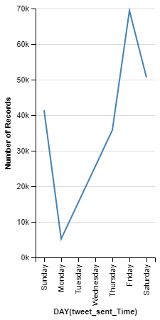

The most retweeted tweets was in sunday and friday. What was the most tweet or topic been retweeted in friday?

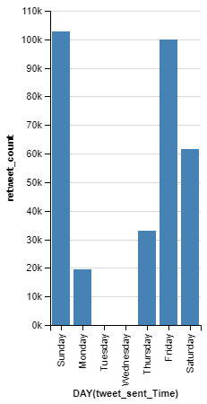

The most active accounts based on tweets number

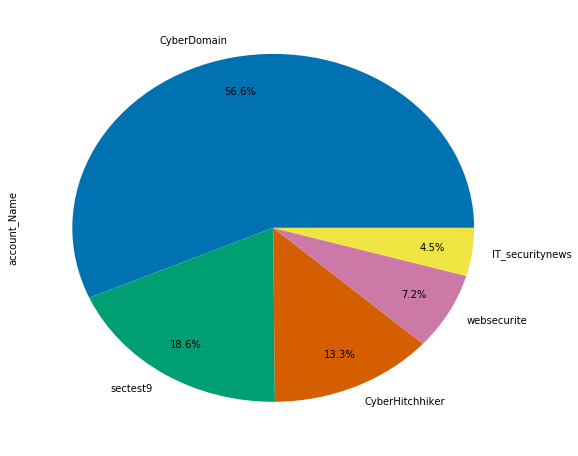

The most active user in Friday and Saturday is CyberDomain

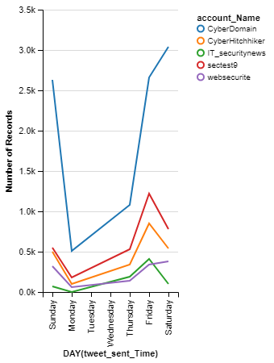

The account's based on their followers numbers

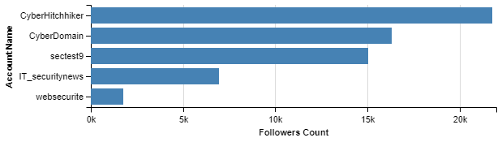

The account's basen on their retweeted tweets

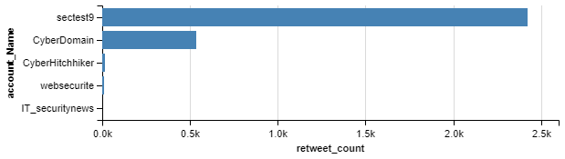

Here we can see each account and their sentiment analysis from their tweets

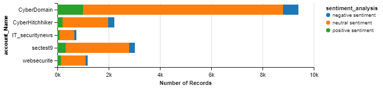

Most liked tweets from the top 5 users

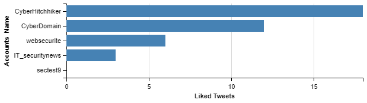

The account based on their growth per year

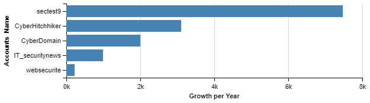

It's not important to have more followers to get retweeted more

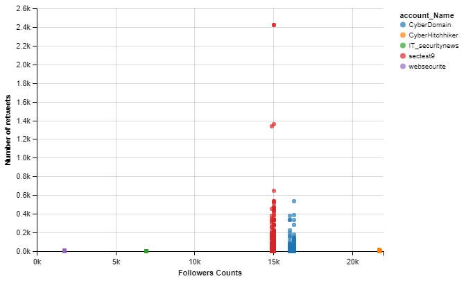

top 3 used platforms

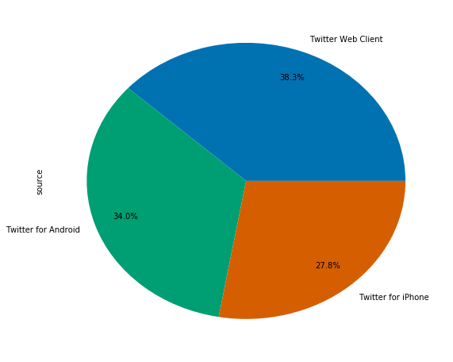

From all the spike in friday we see that the web client is the most used one

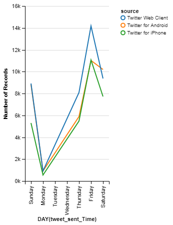

This is a word cload contain the most common words used in tweets And their size based on their frequency

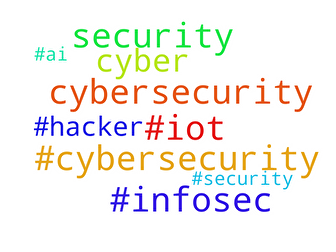

The darker the red dot the higher number of users there interested in cyber security

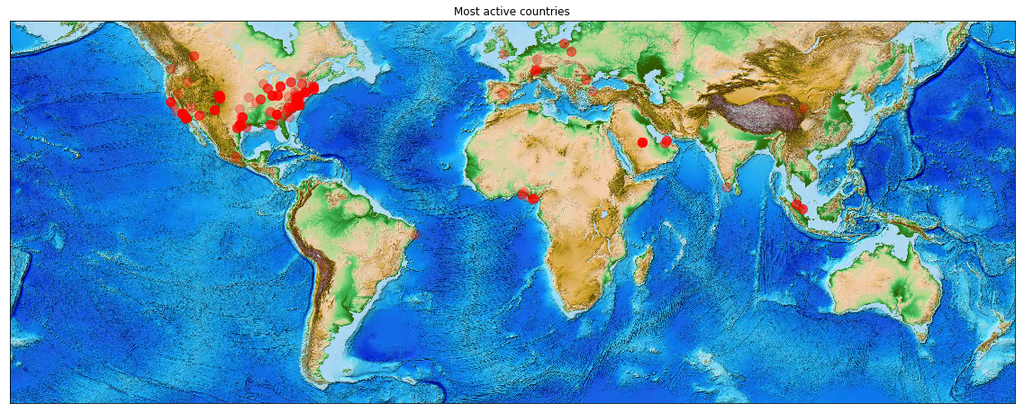